# Environmental impact of utilities

Author

Affiliation

Stan Brouwer

CapGemeni Office Solutions

With the recent focus on sustainability and net-zero by 2024, important business decisions have to be made. To make these decisions, we need to know our current environmental impact. This report models the enivronmental impact of utilities, assuming gas, power and solar. The numbers are based on typical residential building, but numbers for an office can easily be plugged in.

## Utility consumption

Assuming the following usage pattern:

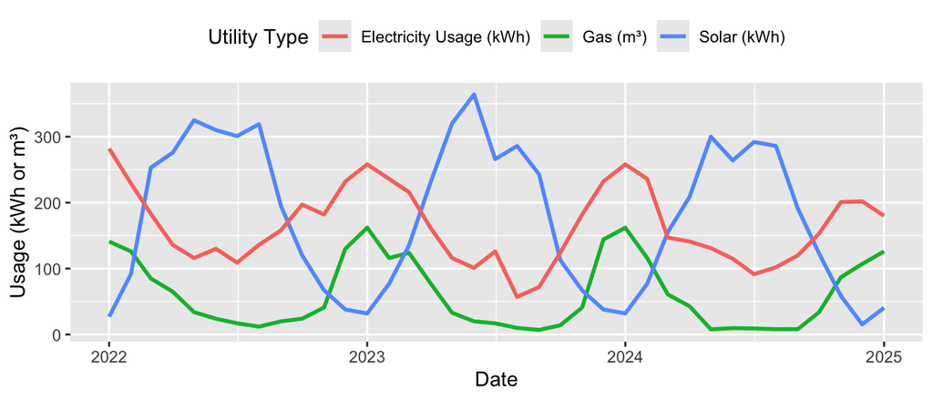

Figure 2.1: Assumed utility usage. Note that energy meters measure net flow, and thus gross solar and power might differ.

**Details**

| Date | Gas (m³) | Electricity Usage (kWh) | Solar (kWh) |
| --- | --- | --- | --- |
| 2025-01-01 | 126.0 | 180.0 | 40.6 |
| 2024-12-01 | 107.0 | 202.0 | 15.4 |
| 2024-11-01 | 86.9 | 201.0 | 58.4 |
| 2024-10-01 | 33.8 | 153.0 | 123.0 |
| 2024-09-01 | 8.2 | 120.0 | 191.0 |
| 2024-08-01 | 8.1 | 102.0 | 286.0 |
| 2024-07-01 | 9.2 | 91.5 | 292.0 |
| 2024-06-01 | 9.7 | 115.0 | 264.0 |
| 2024-05-01 | 7.9 | 131.0 | 300.0 |
| 2024-04-01 | 42.8 | 141.0 | 209.0 |
| 2024-03-01 | 60.9 | 147.0 | 155.0 |
| 2024-02-01 | 116.0 | 236.0 | 77.0 |
| 2024-01-01 | 162.0 | 258.0 | 32.0 |
| 2023-12-01 | 144.0 | 232.0 | 38.0 |
| 2023-11-01 | 41.0 | 182.0 | 67.0 |
| 2023-10-01 | 14.0 | 124.0 | 113.0 |
| 2023-09-01 | 7.0 | 72.0 | 243.0 |
| 2023-08-01 | 10.0 | 57.0 | 286.0 |
| 2023-07-01 | 17.0 | 126.0 | 266.0 |
| 2023-06-01 | 20.0 | 101.0 | 364.0 |
| 2023-05-01 | 33.0 | 116.0 | 320.0 |
| 2023-04-01 | 77.0 | 161.0 | 232.0 |
| 2023-03-01 | 124.0 | 216.0 | 135.0 |
| 2023-02-01 | 116.0 | 236.0 | 77.0 |
| 2023-01-01 | 162.0 | 258.0 | 32.0 |
| 2022-12-01 | 130.0 | 232.0 | 38.0 |
| 2022-11-01 | 41.0 | 182.0 | 67.0 |
| 2022-10-01 | 24.0 | 197.0 | 120.0 |
| 2022-09-01 | 20.0 | 158.0 | 195.0 |
| 2022-08-01 | 12.0 | 136.0 | 319.0 |
| 2022-07-01 | 17.0 | 109.0 | 301.0 |
| 2022-06-01 | 24.0 | 130.0 | 310.0 |
| 2022-05-01 | 34.0 | 116.0 | 325.0 |
| 2022-04-01 | 65.0 | 136.0 | 276.0 |
| 2022-03-01 | 85.0 | 183.0 | 253.0 |
| 2022-02-01 | 126.0 | 229.0 | 92.0 |
| 2022-01-01 | 141.0 | 282.0 | 27.0 |

## Emissions of energy production

To quantify and compare the warming effects of different kind of emissions, the IPPC proposes using the Global Warming Potential (GWP), which can be used to express the warming effect of different emissions to that of CO₂. To calculate our total emissions, we must first determine the emissions caused by the energy production.

### Electricity

The emissions of electricity production depends on the source of the energy, which changes minute-by-minute. During day, a lot of green solar power is generated, and during peaks, gas turbines kick in. Exact information on the current national energy mix is [publicly available](https://ned.nl/nl/dataportaal/energie-productie/elektriciteit/totale-elektriciteitsproductie). [Ember-energy](https://ember-energy.org/data/electricity-data-explorer/#data-tool) calculates the CO₂ emissions based on the energy mix, and has an API (email required) which provides the following numbers:

See also: https://www.cbs.nl/-/media/_excel/2023/06/1-co2-emissie-energieverbruik-rendementen-elektriciteit-2021.xls

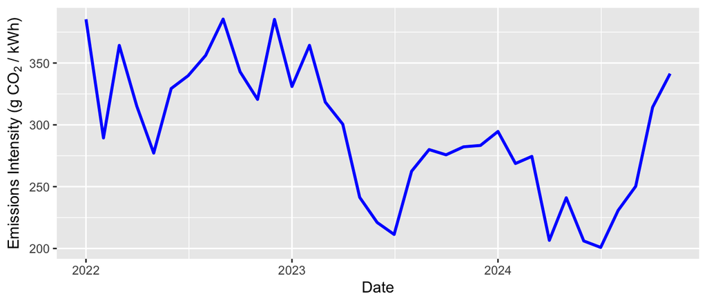

Figure 2.2: CO₂ emissions of the dutch energy production over time

To calculate the emissions caused by our energy consumption, we should account for the differing CO₂ emissions as follows:

$$\text{CO}_2 = \sum_{i=1}^{n} E_i \times F_i$$
With $\text{CO}_2$ is the total produced CO₂ in grams,
$E_i$ the electricity usage for month $i$ in kWh,
$F_i$ the emissions intensity in $g CO₂/kWh$ for that specific month $i$.

### Gas

Calculating the exact emissions caused by gas production is somewhat more complex as gas distributors measure the gas-usage as volume (m³) which is dependent on the temperature, pressure and [gas mix](https://eduweb.eeni.tbm.tudelft.nl/TB141E/?aardgas-conversie), all of which are subject to change. Gas distributors solve this by multiply the measured volume with a correction value to determine the caloric value of the consumed gas (also see [wobbe index](https://eduweb.eeni.tbm.tudelft.nl/TB141E/?aardgas-conversie)). These corrections can be found on the final invoice.

The Netherlands Enterprise Agency (RVO) has calculated the [emission factor](https://www.rvo.nl/sites/default/files/2023-10/CO2-emissiefactor-aardgas-Nederlandse-rapportage-en-ETS-%202023.pdf) for natural gas to be **56.34 kg CO₂ per GJ** of energy. This only includes the emissions caused by burning the gas, not from producing it. The exact number differs by ±2% per year due to differences in the national gas mix, for instance through higher LNG imports.

The CBS [reports](https://www.cbs.nl/nl-nl/onze-diensten/methoden/begrippen/joule) that **1 GJ of natural gas corresponds to 31.6 m³**, thus we can calculate the emissions per m³ as follows:

$$\frac{56.34 \text{ kg}}{\text{GJ}}$$

Since

$$1 \text{ GJ} = 31.6 \text{ m}^3$$
we can compute:

$$\frac{56.34}{31.6} \text{ kg/m}^3$$

which simplifies to:

$$1.78 \text{ kg CO}_2 \text{ per m}^3$$

As the deviations for the emissions of the gas mix are ~2%, we simplify the calculation by not accounting for them.

## Calculations

From the emission factors per energy type the final formula can be determined:

$$\text{CO}_2 = \left( \sum_{i=1}^{n} E_i \times F_i \right) + \left( G \times 1,78 \right)$$
With $\text{CO}_2$ as the total produced CO₂ in grams,
$E_i$ the electricity usage for month $i$ in kWh,
$F_i$ the emissions intensity in $kg CO₂/kWh$ for that specific month $i$. $G$ the total gas usage in m³

Plugging our usage data into this formula gives us the following emissions:

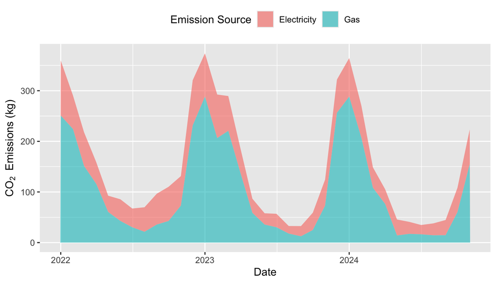

Figure 2.3: Monthly CO₂ Emissions from Energy and Gas

| year | Gas emissions (kg CO₂) | Electricity emissions (kg CO₂) | Total emissions (kg CO₂) |
| --- | --- | --- | --- |
| 2022 | 1279.82 | 721.12 | 2000.94 |
| 2023 | 1361.70 | 551.89 | 1913.59 |
| 2024 | 970.99 | 452.84 | 1423.83 |

**Details**

| date | Electricity | Gas | total | year |
| --- | --- | --- | --- | --- |
| 2024-11-01 | 68.62542 | 154.682 | 223.30742 | 2024 |
| 2024-10-01 | 48.07719 | 60.164 | 108.24119 | 2024 |
| 2024-09-01 | 30.03240 | 14.596 | 44.62840 | 2024 |
| 2024-08-01 | 23.54670 | 14.418 | 37.96470 | 2024 |
| 2024-07-01 | 18.37869 | 16.376 | 34.75469 | 2024 |
| 2024-06-01 | 23.69920 | 17.266 | 40.96520 | 2024 |
| 2024-05-01 | 31.56969 | 14.062 | 45.63169 | 2024 |
| 2024-04-01 | 29.12778 | 76.184 | 105.31178 | 2024 |
| 2024-03-01 | 40.34709 | 108.402 | 148.74909 | 2024 |
| 2024-02-01 | 63.42028 | 206.480 | 269.90028 | 2024 |
| 2024-01-01 | 76.01712 | 288.360 | 364.37712 | 2024 |
| 2023-12-01 | 65.73720 | 256.320 | 322.05720 | 2023 |
| 2023-11-01 | 51.36404 | 72.980 | 124.34404 | 2023 |
| 2023-10-01 | 34.19300 | 24.920 | 59.11300 | 2023 |
| 2023-09-01 | 20.16000 | 12.460 | 32.62000 | 2023 |
| 2023-08-01 | 14.96307 | 17.800 | 32.76307 | 2023 |
| 2023-07-01 | 26.62884 | 30.260 | 56.88884 | 2023 |
| 2023-06-01 | 22.32100 | 35.600 | 57.92100 | 2023 |
| 2023-05-01 | 27.99544 | 58.740 | 86.73544 | 2023 |
| 2023-04-01 | 48.38694 | 137.060 | 185.44694 | 2023 |
| 2023-03-01 | 68.77440 | 220.720 | 289.49440 | 2023 |
| 2023-02-01 | 85.97480 | 206.480 | 292.45480 | 2023 |
| 2023-01-01 | 85.39542 | 288.360 | 373.75542 | 2023 |
| 2022-12-01 | 89.38264 | 231.400 | 320.78264 | 2022 |
| 2022-11-01 | 58.34738 | 72.980 | 131.32738 | 2022 |
| 2022-10-01 | 67.56115 | 42.720 | 110.28115 | 2022 |
| 2022-09-01 | 60.91374 | 35.600 | 96.51374 | 2022 |
| 2022-08-01 | 48.43504 | 21.360 | 69.79504 | 2022 |
| 2022-07-01 | 37.03166 | 30.260 | 67.29166 | 2022 |
| 2022-06-01 | 42.82070 | 42.720 | 85.54070 | 2022 |
| 2022-05-01 | 32.15056 | 60.520 | 92.67056 | 2022 |
| 2022-04-01 | 42.86040 | 115.700 | 158.56040 | 2022 |
| 2022-03-01 | 66.65775 | 151.300 | 217.95775 | 2022 |
| 2022-02-01 | 66.27718 | 224.280 | 290.55718 | 2022 |
| 2022-01-01 | 108.68562 | 250.980 | 359.66562 | 2022 |

If real estate occupancy rate, area or any other measure is known, calculating the carbon footprint per person, workspace or area is trivial.

## Concerns

Clearly, the current calculations only accounts for the direct emissions caused by burning gas, or from producing electricity. (scope 1&2 emissions). Producing and transporting gas and electricity also has a significant impact on the environment.

Furthermore, solar panels return electricity into the grid. How should they be accounted for?